# R Markdown Learning

所有文字和代码来源于rstudio官网rmarkdown文档。

### Installation

```r
install.packages("rmarkdown")
```

### Viridis colors

```r
install.packages("viridis")
```

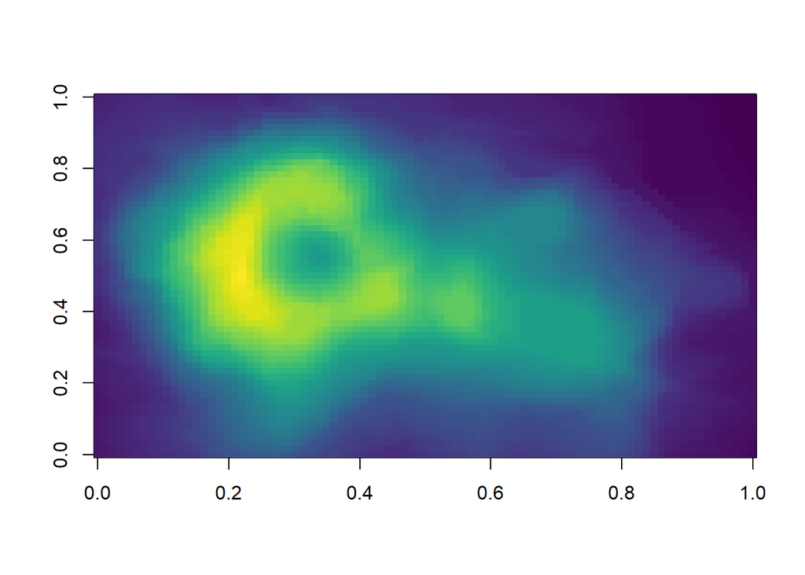

```r
require(viridis)
image(volcano, col=viridis(200))
```

### Rendering output

```r
library(rmarkdown)
render("1-example.Rmd")
```

### [Code Chunks](https://yihui.name/knitr/options/)

You can quickly insert chunks like these into your file with

- the keyboard shortcut Ctrl + Alt + I (OS X: Cmd + Option + I)
- the Add Chunk command in the editor toolbar

or by typing the chunk delimiters ```{r} and ```.

#### Chunk Options

- `include = FALSE` prevents code and results from appearing in the finished file. R Markdown still runs the code in the chunk, and the results can be used by other chunks.
- `echo = FALSE` prevents code, but not the results from appearing in the finished file. This is a useful way to embed figures.
- `message = FALSE` prevents messages that are generated by code from appearing in the finished file.
- `warning = FALSE` prevents warnings that are generated by code from appearing in the finished.
- `fig.cap = "..."` adds a caption to graphical results.

See the [R Markdown Reference Guide](https://www.rstudio.com/wp-content/uploads/2015/03/rmarkdown-reference.pdf) for a complete list of knitr chunk options.

#### Global Options

To set global options that apply to every chunk in your file, call `knitr::opts_chunk$set` in a code chunk. Knitr will treat each option that you pass to `knitr::opts_chunk$set` as a global default that can be overwritten in individual chunk headers.

### Inline Code

```r
colorFunc <- "heat.colors"
```

然后可以在行内代码中使用它，比如运行“r colorFunc”会显示heat.colors。

[figure not shown]

### Code Languages

Rstudio现在支持的语言越来越多了，主要是Python和Shell。可以点击Rstudio上的Insert菜单项查看你的IDE可以支持插入哪些。

以下是我官方显示支持的：

- Python
- SQL
- Bash
- Rcpp
- Stan
- JavaScript
- CSS

### Parameters

R markdown头部可以添加一些YAML参数，比如使用`data`参数方便以后直接调用一些数据。

[figure not shown]

### Tables

表格使用`knitr::kable`函数

[figure not shown]